# Problem Set 5, Solution

Statistics 506, Fall 2020

December 09, 2020

```r
suppressPackageStartupMessages({
  library(tidyverse); library(data.table)
})
```

## About

This is an example solution to [Problem Set 5](https://jbhender.github.io/Stats506/F20/PS5.html) for Stats 506 in Fall 2020.

To build this document, run `Rscript -e "rmarkdown::render('./PS5_solution.Rmd')"` at the command line or `bash ps5_make.sh` to build this document *after* running the solution scripts.

## Question 1

In this question, you were asked to pose and an answer a question about US residences using the 2009 and 2015 Residential Energy Consumption Survey [RECS](https://www.eia.gov/consumption/residential/) data. Additionally, you were asked to use `data.table` for data manipulations. This is an example question, yours will differ.

### a, Question

> Which Census Divisions, if any, have the largest disparity in home internet access between urban and rural residences?

I will answer this question using the variable `INTERNET` to identify home internet access, `DIVISION` to represent Census Division, and `UATYP10` for urban / rural status. In addition, I will use the survey weights `NWEIGHT` to estimate population proportions and the replicate weights `BRRWT1`-`BRRWT96` to compute standard errors.

### b, Analysis

The analysis for this question is in `ps5_q1.R` which can be found at the [Stats506_F20](https://github.com/jbhender/Stats506_F20/) repository.

```r
source('./ps5_q1.R')
```

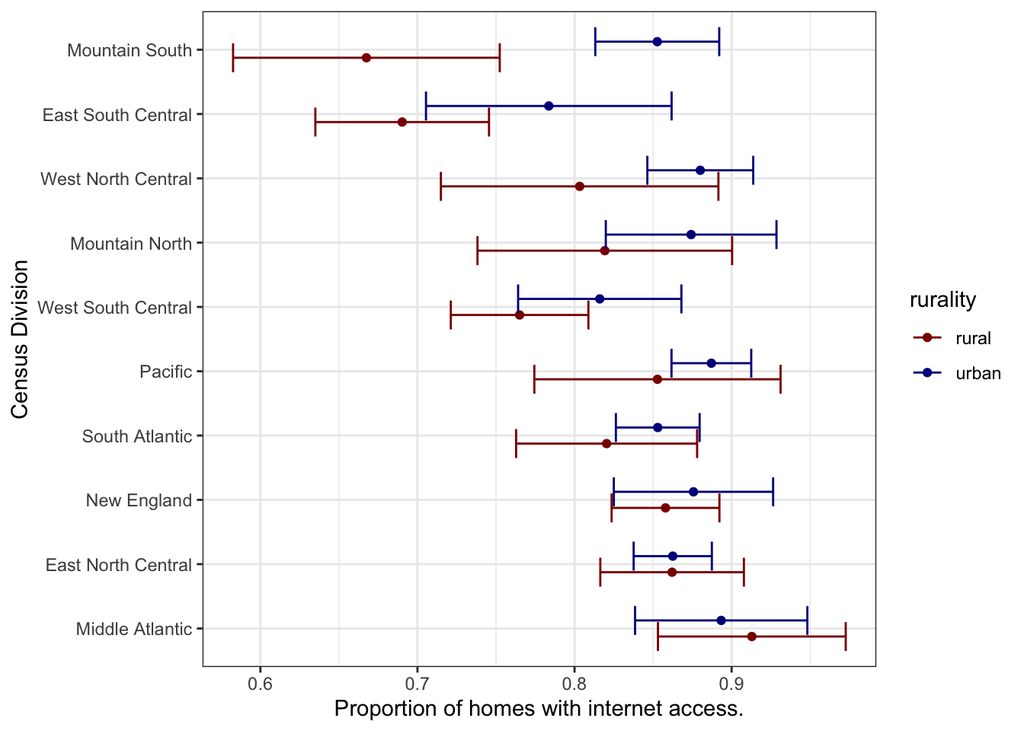

**Figure 1.** *Proportion of residences with home internet access in 2015.* Values are estimated using the 2015 Residential Energy Consumption Survey data.

```r
cap1 = paste(
  "**Figure 1.**",
  "*Proportion of residences with home internet access in 2015.*",
  "Values are estimated using the 2015 Residential Energy Consumption Survey",
  "data."
)
p1
```

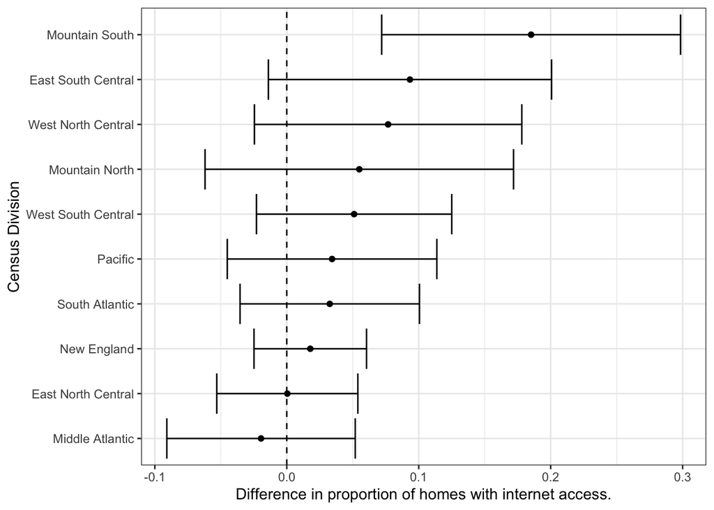

```r
cap2 = paste(
  "**Figure 2.**",
  "*Proportion of residences with home internet access in 2015.*",
  "Values are estimated using the 2015 Residential Energy Consumption Survey",
  "data."
)
p2
```

```r
tabcap1 = paste(
  "**Table 1.** *Home internet access and urban/rural disparity by Census",
  "Division.*"
)
tab[.N:1] %>%
  knitr::kable(format = 'html', caption = tabcap1) %>%
  kableExtra::kable_styling("striped", full_width = TRUE) %>%
  kableExtra::add_header_above(
    header = c(' ' = 1, 'Home Internent Access, proportion (95% CI)' = 3)
  )
```

**Table 1.** *Home internet access and urban/rural disparity by Census Division.*

| Census Division | Home Internent Access, proportion (95% CI) Rural | Home Internent Access, proportion (95% CI) Urban | Home Internent Access, proportion (95% CI) Disparity |
| --- | --- | --- | --- |
| Mountain South | 0.67 (0.58, 0.75) | 0.85 (0.81, 0.89) | 0.19 (0.07, 0.30) |
| East South Central | 0.69 (0.63, 0.75) | 0.78 (0.71, 0.86) | 0.09 (-0.01, 0.20) |
| West North Central | 0.80 (0.71, 0.89) | 0.88 (0.85, 0.91) | 0.08 (-0.02, 0.18) |
| Mountain North | 0.82 (0.74, 0.90) | 0.87 (0.82, 0.93) | 0.05 (-0.06, 0.17) |
| West South Central | 0.77 (0.72, 0.81) | 0.82 (0.76, 0.87) | 0.05 (-0.02, 0.13) |
| Pacific | 0.85 (0.77, 0.93) | 0.89 (0.86, 0.91) | 0.03 (-0.05, 0.11) |
| South Atlantic | 0.82 (0.76, 0.88) | 0.85 (0.83, 0.88) | 0.03 (-0.04, 0.10) |
| New England | 0.86 (0.82, 0.89) | 0.88 (0.83, 0.93) | 0.02 (-0.02, 0.06) |
| East North Central | 0.86 (0.82, 0.91) | 0.86 (0.84, 0.89) | 0.00 (-0.05, 0.05) |
| Middle Atlantic | 0.91 (0.85, 0.97) | 0.89 (0.84, 0.95) | -0.02 (-0.09, 0.05) |

### c, Conclusion

Based on these data, only the Mountain South region has an urban-rural disparity in home internet access whose 95% confidence interval does lies entirely above zero. The Mountain South division has an estimated disparity of 0.19 (0.07, 0.30) [Urban = 0.85 (0.81, 0.89); Rural = 0.67 (0.58, 0.75)] while all other divisions have an estimated disparity of less than 10%.

### Question 2

All three models use logistic regression and cubic smoothing splines to model the relationship of the outcome with with age. However, the models differ in how they account for each subject contributing multiple teeth.  
Throughout, we focus on the conditional predictions and therefore do not use the survey weights or design. All models are fit using `mgcv::bam()` in R.

1. *Model 1.* Same relationship for all teeth, random intercepts for subjects, using formula: `perm_tooth ~ tooth + s(age, bs = 'cs') + s(id, bs = 're')`.
2. *Model 2.* Each tooth has its own smooth relationship with age, random intercepts for subjects, using formula: `perm_tooth ~ tooth + s(age, bs = 'cs', by = 'tooth') + s(id, bs = 're')`.
3. *Model 3.* Each tooth is modeled separately, so that the random intercepts for subject are no longer needed and each tooth has its own relationship with age:  
   `perm_tooth ~ s(age, bs = 'cs')`.

Examining **Table 2** below, Models 2 and 3 both perform better than Model 1 indicating not all teeth share a common relation with age. Model 2, making predictions on all teeth jointly, performs marginally better than Model 3 though the difference is likely too small to be meaningful.

```r
foo = load('ps5_q2_cross_entropy_loss.RData')


loss = data.table(
  Model = paste('Model', 1:3),
  loss = round(unlist(loss), 4)
)

## Approximate std error
se = loss_by_cohort[,
               lapply(.SD, function(x) sd(x) / sqrt(.N)),
               .SDcols = grep('^yhat', names(loss_by_cohort))
               ] %>%
  melt(
    measure.vars = grep('^yhat', names(loss_by_cohort), value = TRUE),
    variable.name = 'Model',
    value.name = 'se'
    )
se[, Model := str_replace_all(Model, 'yhat_v', 'Model ')]


## Approximate confidence interval
ci_fmt = '%6.4f (%6.4f, %6.4f)'
m = qnorm(.975)
tab2 = merge(loss, se, by = 'Model') %>%
  .[, .(Model, Loss = sprintf(ci_fmt, loss, loss - m * se, loss + m * se))]
```

```r
tabcap2 = paste(
  "**Table 2.** *Cross-validated cross-entropy loss for models predicting",
  "the presence of a permanent tooth.* Confidence intervals are approximate",
  "and represent 1.96 times the standard error of the loss across each of the",
  "four folds."
)

tab2 %>%
  knitr::kable(format = 'html', caption = tabcap2) %>%
  kableExtra::kable_styling("striped", full_width = TRUE)
```

**Table 2.** *Cross-validated cross-entropy loss for models predicting the presence of a permanent tooth.* Confidence intervals are approximate and represent 1.96 times the standard error of the loss across each of the four folds.

| Model | Loss |
| --- | --- |
| Model 1 | 0.3600 (0.3495, 0.3705) |
| Model 2 | 0.3097 (0.2975, 0.3219) |
| Model 3 | 0.3104 (0.2985, 0.3223) |